# SISCER Survival Course R Practicum Day 1

Pamela Shaw

2026-07-08

```r
knitr::opts_chunk$set(echo = TRUE)
library(survival)
library(ggsurvfit)
library(km.ci)
library(survminer) #ggsurvplot
library(gtsummary) #survfit table
library(lmtest) # likelihood ratio test
```

## Dataset: `veteran` from the **survival** package

```r
data(cancer, package = "survival")

# convert days to months
veteran$months <- veteran$time / (365.25 / 12)
head(veteran)
```

```
##   trt celltype time status karno diagtime age prior     months
## 1   1 squamous   72      1    60        7  69     0  2.3655031
## 2   1 squamous  411      1    70        5  64    10 13.5030801
## 3   1 squamous  228      1    60        3  38     0  7.4907598
## 4   1 squamous  126      1    60        9  63    10  4.1396304
## 5   1 squamous  118      1    70       11  65    10  3.8767967
## 6   1 squamous   10      1    20        5  49     0  0.3285421
```

## Exercises

1. **Kaplan-Meier Curves**: Plot Kaplan-Meier survival curves by cell type.
   - Make one version with **pointwise confidence intervals**.
   - Make another with **simultaneous confidence bands**.
2. **Log-Rank Test**: Compute and interpret the log-rank statistic comparing survival by cell type.
3. **Assumptions**: What assumption is required for the log-rank test to be most efficient?
4. **Check Proportional Hazards**: Check the proportional hazards assumption.
   - Graphically using log(-log(S(t))).
   - Using a formal test via `cox.zph`.
   - Conclude whether the log-rank test is reasonable in this case.
5. **Peto-Peto Test**: Compute the Peto-Peto test and compare results to part 2.
6. **Improved Visualization**: Revisit your Kaplan-Meier curves and improve the plot aesthetics.
   - Add confidence intervals.
   - Include a risk table.
   - Modify color, font size, or confidence interval format (shaded vs lines).
7. **Restricted Mean Survival**: Compare the restricted mean survival times between cell types, restricted to 1 year.
8. **Cox Proportional Hazards Model**: Fit a multivariable Cox model adjusting for cell type, treatment, prior therapy, and Karnofsky score.
   1. Do the HRs for cell type summarize the stratified K-M curves well?
   2. What is the HR for adeno vs squamous cell type?
   3. How important is cell type in the model? Compare this to the unadjusted log-rank result.
   4. What is the HR associated with a 10-point increase in Karnofsky score?
   5. Evaluate the PH assumption using `cox.zph`.
   6. Refit the model stratifying on cell type. Are any PH violations still present?

## Answers

### 1. Kaplan-Meier Curves

#### Pointwise confidence bands

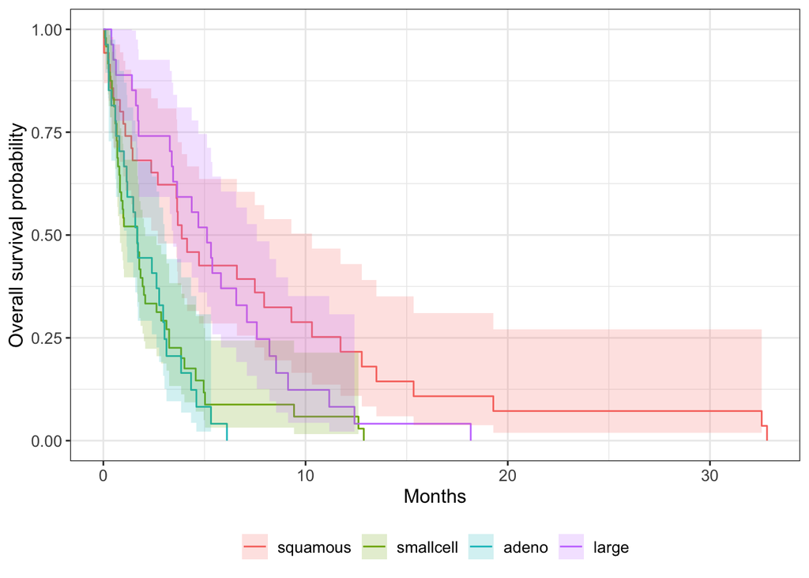

```r
vfit.surv <- survfit(Surv(months, status) ~ celltype, data = veteran, conf.type = "log-log")
survfit2(Surv(months, status) ~ celltype, data = veteran) %>%
  ggsurvfit() +
  labs(
    x = "Months",
    y = "Overall survival probability"
  ) +
  add_confidence_interval()
```

#### Simultaneous confidence bands

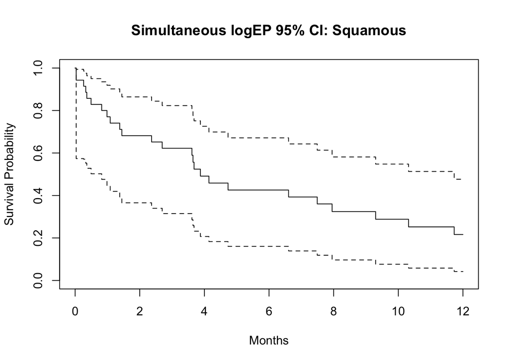

```r
# Subset to one cell type, e.g., "squamous"
# Can repeat for each cell type
squamous_data <- subset(veteran, celltype == "squamous")

# Create surv object
surv_simul <- survfit(Surv(months, status) ~ 1, data = squamous_data)

# Compute simultaneous confidence band
fit.simul <- km.ci(surv_simul, method = "logep")

# Plot
plot(fit.simul, xlim = c(0, 12), xlab = "Months", ylab = "Survival Probability")
title("Simultaneous logEP 95% CI: Squamous")
```

### 2. Log-Rank Test

The log-rank test for equality of survival curves across cell types yielded a p-value < 0.001, indicating strong evidence of a significant difference in survival distributions among the cell types.

```r
survdiff(Surv(months, status) ~ celltype, data = veteran)
```

```
## Call:
## survdiff(formula = Surv(months, status) ~ celltype, data = veteran)
##
##                     N Observed Expected (O-E)^2/E (O-E)^2/V
## celltype=squamous  35       31     47.7      5.82     10.53
## celltype=smallcell 48       45     30.1      7.37     10.20
## celltype=adeno     27       26     15.7      6.77      8.19
## celltype=large     27       26     34.5      2.12      3.02
##
##  Chisq= 25.4  on 3 degrees of freedom, p= 1e-05
```

### 3. Assumptions

The log-rank test assumes proportional hazards, meaning the hazard ratios between groups are constant over time.

### 4. Check Proportional Hazards

The complementary log-log curves are not parallel, suggesting a violation to the proportional hazards assumption. In addition, the score test from cox.zph (p = 0.03) rejects the proportional-hazards assumption.

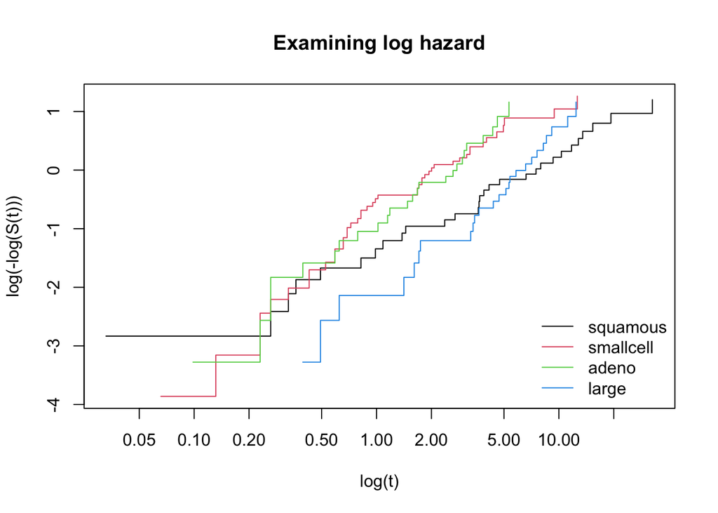

```r
# Graphical check
plot(vfit.surv, fun = "cloglog", col = 1:4, xlab = "log(t)", ylab = "log(-log(S(t)))", main = "Examining log hazard")
legend("bottomright", legend = levels(veteran$celltype), col = 1:4, lty = 1, bty = "n")
```

```r
# Formal test
vfit.cox.unadj <- coxph(Surv(months, status) ~ celltype, data = veteran)
vfit.ph <- cox.zph(vfit.cox.unadj,terms=F)
print(vfit.ph)
```

```
##                   chisq df     p
## celltypesmallcell  1.44  1 0.229
## celltypeadeno      2.17  1 0.141
## celltypelarge      4.70  1 0.030
## GLOBAL             8.87  3 0.031
```

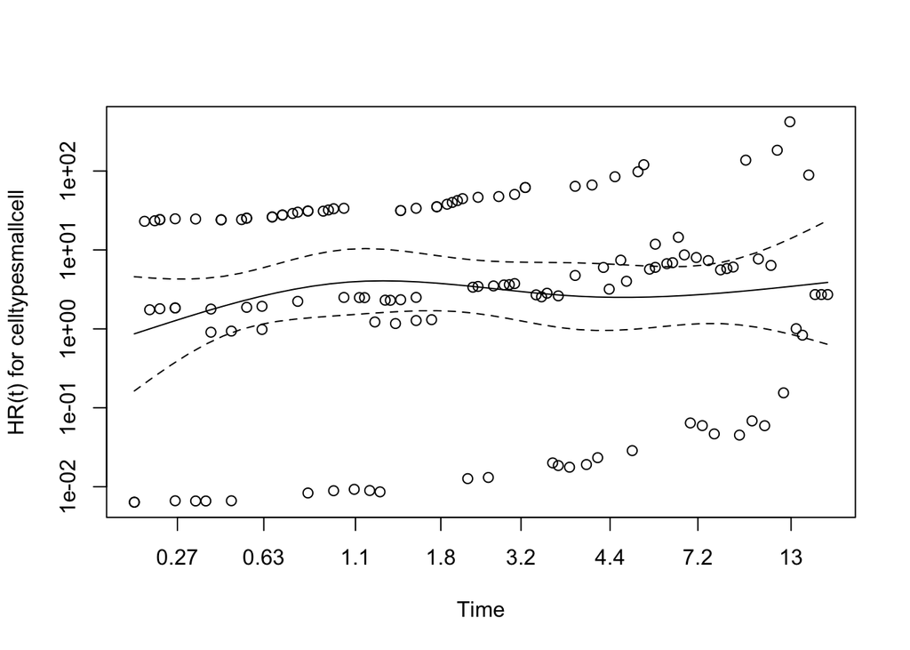

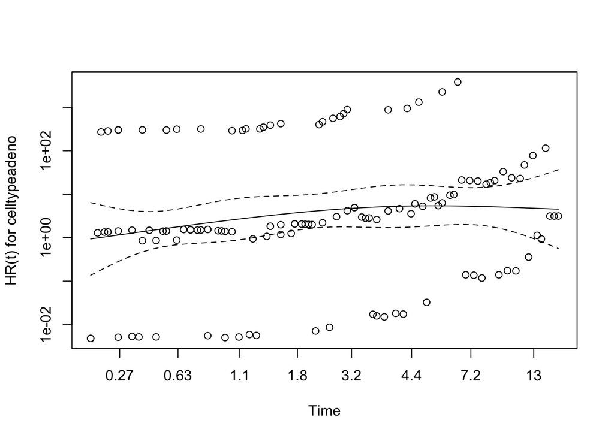

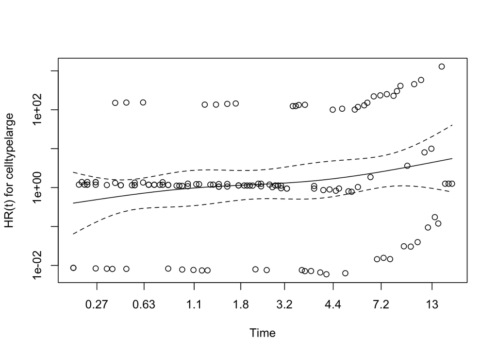

```r
plot(vfit.ph, hr = TRUE)
```

```r
### Note we added "terms=F" so that we would get a plot for each coefficient. Without that in the cox.zph statement there would only one plot for cell type, and an overall pvalue for that variable.
```

### 5. Peto-Peto Test

Like the log-rank test, the Peto-Peto test for equality of survival curves across cell types yielded a p-value < 0.001, indicating strong evidence of a significant difference in survival distributions among the cell types.

```r
survdiff(Surv(months, status) ~ celltype, data = veteran, rho = 1)
```

```
## Call:
## survdiff(formula = Surv(months, status) ~ celltype, data = veteran,
##     rho = 1)
##
##                     N Observed Expected (O-E)^2/E (O-E)^2/V
## celltype=squamous  35    13.39     20.2      2.27      5.05
## celltype=smallcell 48    28.43     19.0      4.67      9.33
## celltype=adeno     27    16.07     10.8      2.56      4.23
## celltype=large     27     9.56     17.5      3.59      7.57
##
##  Chisq= 19.7  on 3 degrees of freedom, p= 2e-04
```

### 6. Improved Visualization

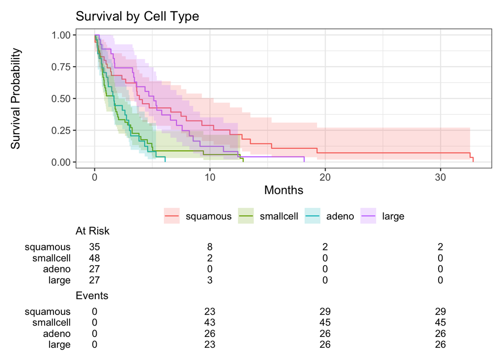

```r
survfit2(Surv(months, status) ~ celltype, data = veteran) %>%
  ggsurvfit() +
  add_confidence_interval(type = "ribbon") +
  add_risktable() +
  labs(title = "Survival by Cell Type", x = "Months", y = "Survival Probability")
```

### 7. Restricted Mean Survival

```r
print(vfit.surv, rmean = 12)
```

```
## Call: survfit(formula = Surv(months, status) ~ celltype, data = veteran,
##     conf.type = "log-log")
##
##                     n events rmean* se(rmean) median 0.95LCL 0.95UCL
## celltype=squamous  35     31   5.61     0.797   3.88   1.446    7.95
## celltype=smallcell 48     45   2.55     0.459   1.68   0.789    2.00
## celltype=adeno     27     26   2.15     0.326   1.68   0.789    2.96
## celltype=large     27     26   5.33     0.673   5.13   3.285    7.10
##     * restricted mean with upper limit =  12
```

```r
### IF we wanted to compare two groups, we could form our own t-test by hand, following code we did in Lecture t=diff/se. (I dont know of an easier way in R, but I'm sure there must be).

# for differnece or the RMST (rmean) between squamous and small cell have
diff=5.61-2.55
## since independent groups, add variance to compute SE for difference
se.diff<-sqrt(.797^2 + .459^2)
Zstat=diff/se.diff
pvalue <- 2 * (pnorm(abs(Zstat), lower.tail = FALSE))
pvalue
```

```
## [1] 0.0008775819
```

```r
### Note this would be more precise as t-statistic but would need to calculate Saitterthwhaite's formula to calculate df by hand.
## https://www.statisticshowto.com/satterthwaite-formula/
##Or perhaps instead find an R package to do this test of difference for RMST properly for us!
```

### 8. Cox Proportional Hazards Model

#### Part (i)

Yes, the HRs for cell type summarize the stratified K-M curves well; for example, the adeno group has the highest hazard ratio, and we can visually see from the K-M plots that it has the fastest drop in survival.

```r
# Multivariable Cox model
vfit.cox.mv <- coxph(Surv(months, status) ~ celltype + trt + prior + karno, data = veteran)
summary(vfit.cox.mv)
```

```
## Call:
## coxph(formula = Surv(months, status) ~ celltype + trt + prior +
##     karno, data = veteran)
##
##   n= 137, number of events= 128
##
##                        coef exp(coef)  se(coef)      z Pr(>|z|)
## celltypesmallcell  0.833094  2.300425  0.269632  3.090    0.002 **
## celltypeadeno      1.174203  3.235562  0.299650  3.919 8.91e-05 ***
## celltypelarge      0.393718  1.482483  0.282233  1.395    0.163
## trt                0.255036  1.290508  0.201489  1.266    0.206
## prior              0.008354  1.008389  0.020675  0.404    0.686
## karno             -0.031456  0.969033  0.005201 -6.048 1.47e-09 ***
## ---
## Signif. codes:  0 '***' 0.001 '**' 0.01 '*' 0.05 '.' 0.1 ' ' 1
##
##                   exp(coef) exp(-coef) lower .95 upper .95
## celltypesmallcell     2.300     0.4347    1.3561     3.902
## celltypeadeno         3.236     0.3091    1.7984     5.821
## celltypelarge         1.482     0.6745    0.8526     2.578
## trt                   1.291     0.7749    0.8695     1.915
## prior                 1.008     0.9917    0.9683     1.050
## karno                 0.969     1.0320    0.9592     0.979
##
## Concordance= 0.737  (se = 0.021 )
## Likelihood ratio test= 61.23  on 6 df,   p=3e-11
## Wald test            = 63.37  on 6 df,   p=9e-12
## Score (logrank) test = 66.56  on 6 df,   p=2e-12
```

#### Part (ii)

The hazard ratio for adeno vs squamous cell type is 3.24.

#### Part (iii)

```r
# Likelihood ratio test (LRT) for cell type
vfit.cox.mv0 <- coxph(Surv(months, status) ~ trt + prior + karno, data = veteran)
lrtest(vfit.cox.mv0, vfit.cox.mv)
```

```
## Likelihood ratio test
##
## Model 1: Surv(months, status) ~ trt + prior + karno
## Model 2: Surv(months, status) ~ celltype + trt + prior + karno
##   #Df  LogLik Df  Chisq Pr(>Chisq)
## 1   3 -483.93
## 2   6 -474.83  3 18.188  0.0004023 ***
## ---
## Signif. codes:  0 '***' 0.001 '**' 0.01 '*' 0.05 '.' 0.1 ' ' 1
```

```r
# unadjusted log rank result
survdiff(Surv(months, status) ~ celltype, data = veteran)
```

```
## Call:
## survdiff(formula = Surv(months, status) ~ celltype, data = veteran)
##
##                     N Observed Expected (O-E)^2/E (O-E)^2/V
## celltype=squamous  35       31     47.7      5.82     10.53
## celltype=smallcell 48       45     30.1      7.37     10.20
## celltype=adeno     27       26     15.7      6.77      8.19
## celltype=large     27       26     34.5      2.12      3.02
##
##  Chisq= 25.4  on 3 degrees of freedom, p= 1e-05
```

The p-value from LRT from multivariate model and logrank test from univariable model were very similar, both <0.001. The unadjusted test was a little smaller, which isnt that suprising as some of its significance may have been due to correlation with other variables left out of the model

#### Part (iv)

The HR associated with a 10-point increase in Karnofsky score is $exp(-0.0315 * 10) = 0.73$.

You could get confidence interval for this quantity in this way (note I am sure there is a function in R to find the confidence interval for a function of a regression coefficient. Perhpas one of you could find it. But for a monotonic transformation, it’s easy to do confidence interval for 10*beta on log-scale and then exponentiate.

```r
beta.karno<-summary(vfit.cox.mv)$coef[6,1]
se.beta.karno<-summary(vfit.cox.mv)$coef[6,3]
LL<-10*beta.karno - qnorm(.975)*10*se.beta.karno
UL<-10*beta.karno + qnorm(.975)*10*se.beta.karno

round(c(exp(LL),exp(UL)),3)
```

```
## [1] 0.659 0.808
```

#### Part (v)

```r
# PH assumption
vfit.mv.ph <- cox.zph(vfit.cox.mv,terms=F)
print(vfit.mv.ph)
```

```
##                    chisq df       p
## celltypesmallcell  4.080  1 0.04339
## celltypeadeno      7.011  1 0.00810
## celltypelarge      5.083  1 0.02415
## trt                0.188  1 0.66465
## prior              2.404  1 0.12099
## karno             12.734  1 0.00036
## GLOBAL            26.149  6 0.00021
```

#### Part (vi)

```r
# Stratified model
vfit.cox.strat <- coxph(Surv(months, status) ~ trt + prior + karno + strata(celltype), data = veteran)
summary(vfit.cox.strat)
```

```
## Call:
## coxph(formula = Surv(months, status) ~ trt + prior + karno +
##     strata(celltype), data = veteran)
##
##   n= 137, number of events= 128
##
##            coef exp(coef)  se(coef)      z Pr(>|z|)
## trt    0.220628  1.246860  0.201543  1.095    0.274
## prior  0.014911  1.015023  0.021111  0.706    0.480
## karno -0.036181  0.964465  0.005585 -6.478 9.29e-11 ***
## ---
## Signif. codes:  0 '***' 0.001 '**' 0.01 '*' 0.05 '.' 0.1 ' ' 1
##
##       exp(coef) exp(-coef) lower .95 upper .95
## trt      1.2469     0.8020    0.8400    1.8509
## prior    1.0150     0.9852    0.9739    1.0579
## karno    0.9645     1.0368    0.9540    0.9751
##
## Concordance= 0.697  (se = 0.026 )
## Likelihood ratio test= 42.8  on 3 df,   p=3e-09
## Wald test            = 42.88  on 3 df,   p=3e-09
## Score (logrank) test = 45.95  on 3 df,   p=6e-10
```

```r
vfit.strat.ph <- cox.zph(vfit.cox.strat)
print(vfit.strat.ph)
```

```
##         chisq df     p
## trt    0.0714  1 0.789
## prior  1.5454  1 0.214
## karno  6.5339  1 0.011
## GLOBAL 9.5940  3 0.022
```

From these results, we see some residual violations of the PH assumption, but things got a bit better.